# temp_chapter2.Rmd

2023-11-14

#### **Task 1 - Read student2014 data into R**

```r
knitr::opts_chunk$set(echo = TRUE)
student2014<-read.csv("learning2014.csv")
library(tidyverse)
glimpse(student2014)
```

```
## Rows: 166
## Columns: 8
## $ X        <int> 1, 2, 3, 4, 5, 6, 7, 8, 9, 10, 11, 12, 13, 14, 15, 16, 17, 18…
## $ gender   <chr> "F", "M", "F", "M", "M", "F", "M", "F", "M", "F", "M", "F", "…
## $ Age      <int> 53, 55, 49, 53, 49, 38, 50, 37, 37, 42, 37, 34, 34, 34, 35, 3…
## $ attitude <dbl> 3.7, 3.1, 2.5, 3.5, 3.7, 3.8, 3.5, 2.9, 3.8, 2.1, 3.9, 3.8, 2…
## $ deep     <dbl> 3.583333, 2.916667, 3.500000, 3.500000, 3.666667, 4.750000, 3…
## $ stra     <dbl> 3.375, 2.750, 3.625, 3.125, 3.625, 3.625, 2.250, 4.000, 4.250…
## $ surf     <dbl> 2.583333, 3.166667, 2.250000, 2.250000, 2.833333, 2.416667, 1…
## $ Points   <int> 25, 12, 24, 10, 22, 21, 21, 31, 24, 26, 31, 31, 23, 25, 21, 3…
```

**Data dimensions** The dimensions of this dataset should be 166 x 7 (original dimension when created). But reading it back into R using read.csv function adds an ID column at the start, which is titled X because its a blank column name (automated by R) and hence now it has 8 columns instead of 7.

**How this data was created** The original raw data came from: http://www.helsinki.fi/~kvehkala/JYTmooc/JYTOPKYS3-data.txt, which is a tab delimited text file. This was read into R using read.delim2() function (alternatively read.table function). Then 3 groups of questions of interest *Deep questions* = ‘deep’ column,*Strategic questions* = ‘stra’ column and *surface questions* = ‘surf’ column were applied (to select subset of columns from the raw data) and then data was summarised by rowMeans() function for each of the subset of questions. Then we filtered the data so that students with exam points of 0 were eliminated from the dataset using dplyr::filter() function.

#====================================================================================================================

#### **Task 2 - Graphical overview**

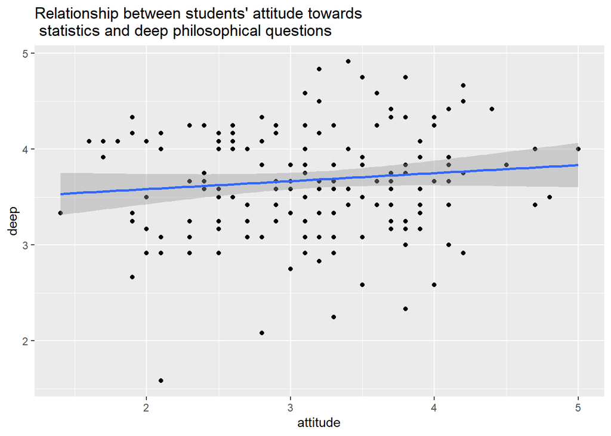

```r
library(ggplot2)
library(GGally)
ggexplore<-ggplot(student2014,aes(x=attitude,y=deep))+
  geom_point()+
  geom_smooth(method = "lm")+
  ggtitle("Relationship between students' attitude towards \n statistics and deep philosophical questions")
ggexplore
```

**Interpretation**: Maybe slight positive relationship, suggesting that people who scored higher on their attitude towards statistics is more likely to score higher on philosophical questions.

##### Pairs plot

This type of plot is great at comparing all the variables against all the others at the same time, rather than plotting only 2 variables at a time with a ggplot+geom_point() function above.

```r
student2014<-student2014[,2:8] #this is needed now because we want the pairs plot to look less messy.
str(student2014)
```

```
## 'data.frame':    166 obs. of  7 variables:
##  $ gender  : chr  "F" "M" "F" "M" ...
##  $ Age     : int  53 55 49 53 49 38 50 37 37 42 ...
##  $ attitude: num  3.7 3.1 2.5 3.5 3.7 3.8 3.5 2.9 3.8 2.1 ...
##  $ deep    : num  3.58 2.92 3.5 3.5 3.67 ...
##  $ stra    : num  3.38 2.75 3.62 3.12 3.62 ...
##  $ surf    : num  2.58 3.17 2.25 2.25 2.83 ...
##  $ Points  : int  25 12 24 10 22 21 21 31 24 26 ...
```

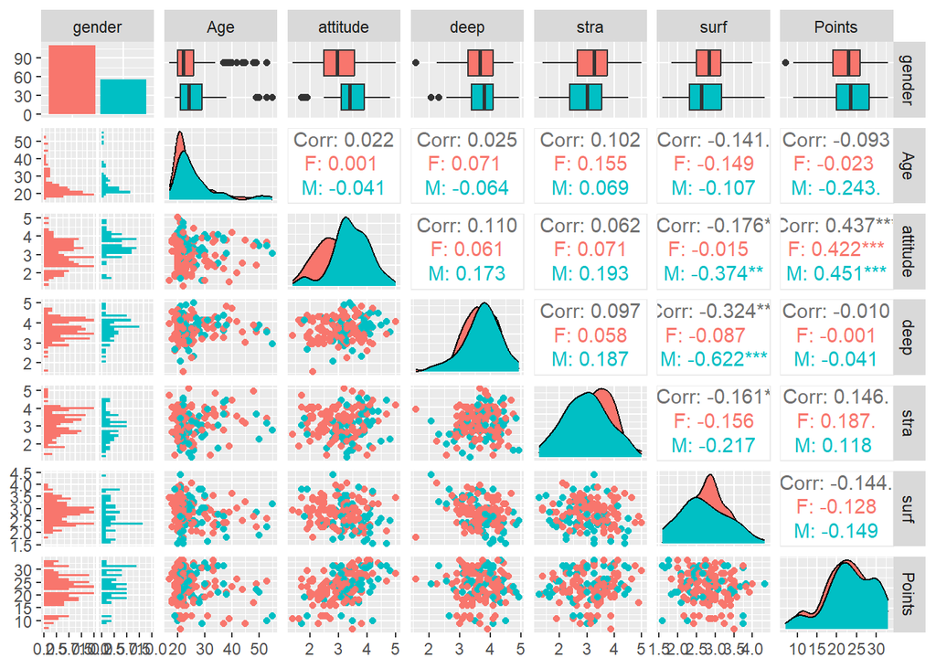

```r
pairs<- ggpairs(student2014, mapping = aes(col=gender), lower = list(combo = wrap("facethist", bins = 30)))
pairs
```

**Interpretation**:

##### A bit deeper

The most significant relationships are between exam points and attitude towards statistics - students with more positive attitude towards statistics are more likely to score higher in exams (perhaps predictable). There is a significant (negative slope) relationship between responses to deep philosophical questions and surface questions - when people score higher on deep questions, they are likely to score lower on surface questions. This relationship is particularly noticeable amongst males. Similar, but weaker relation is true for surface question responses and strategic responses (but no difference in responses between genders).

#====================================================================================================================

#### **Task 3 - Regression on exam score**

```r
str(student2014)
```

```
## 'data.frame':    166 obs. of  7 variables:
##  $ gender  : chr  "F" "M" "F" "M" ...
##  $ Age     : int  53 55 49 53 49 38 50 37 37 42 ...
##  $ attitude: num  3.7 3.1 2.5 3.5 3.7 3.8 3.5 2.9 3.8 2.1 ...
##  $ deep    : num  3.58 2.92 3.5 3.5 3.67 ...
##  $ stra    : num  3.38 2.75 3.62 3.12 3.62 ...
##  $ surf    : num  2.58 3.17 2.25 2.25 2.83 ...
##  $ Points  : int  25 12 24 10 22 21 21 31 24 26 ...
```

```r
mod1<-lm(formula= Points ~ attitude+Age+deep+stra+surf,data=student2014)
summary(mod1)
```

```
##
## Call:
## lm(formula = Points ~ attitude + Age + deep + stra + surf, data = student2014)
##
## Residuals:
##      Min       1Q   Median       3Q      Max
## -17.4759  -3.2812   0.3804   3.5381  11.4897
##
## Coefficients:
##             Estimate Std. Error t value Pr(>|t|)
## (Intercept) 18.30059    5.24076   3.492  0.00062 ***
## attitude     3.43200    0.56991   6.022 1.14e-08 ***
## Age         -0.09650    0.05335  -1.809  0.07234 .
## deep        -1.04374    0.78179  -1.335  0.18375
## stra         0.96551    0.53917   1.791  0.07523 .
## surf        -1.10529    0.84009  -1.316  0.19016
## ---
## Signif. codes:  0 '***' 0.001 '**' 0.01 '*' 0.05 '.' 0.1 ' ' 1
##
## Residual standard error: 5.249 on 160 degrees of freedom
## Multiple R-squared:  0.2311, Adjusted R-squared:  0.2071
## F-statistic:  9.62 on 5 and 160 DF,  p-value: 4.803e-08
```

Surface and deep questions don’t have any significant relationship with exam points. So lets remove them, but before that we can be fancy and use a formal variable selection package to confirm our suspesions/support our decision.

```r
library(olsrr)
ols_step_all_possible(mod1)
```

```
##    Index N                  Predictors     R-Square Adj. R-Square Mallow's Cp
## 1      1 1                    attitude 0.1905536672   0.185618019    6.444236
## 4      2 1                        stra 0.0213517768   0.015384410   41.654826
## 5      3 1                        surf 0.0208387755   0.014868280   41.761581
## 2      4 1                         Age 0.0086844365   0.002639829   44.290875
## 3      5 1                        deep 0.0001029919  -0.005993941   46.076658
## 8      6 2               attitude stra 0.2048096617   0.195052725    5.477591
## 6      7 2                attitude Age 0.2011434849   0.191341564    6.240515
## 9      8 2               attitude surf 0.1952865878   0.185412804    7.459324
## 7      9 2               attitude deep 0.1939911024   0.184101423    7.728912
## 15    10 2                   stra surf 0.0363412029   0.024517169   40.535555
## 12    11 2                    Age surf 0.0340077514   0.022155086   41.021142
## 11    12 2                    Age stra 0.0331743748   0.021311484   41.194566
## 14    13 2                   deep surf 0.0244545065   0.012484623   43.009154
## 13    14 2                   deep stra 0.0219453518   0.009944681   43.531304
```

[output cut: 17 more lines]

##### **All possible regression** method

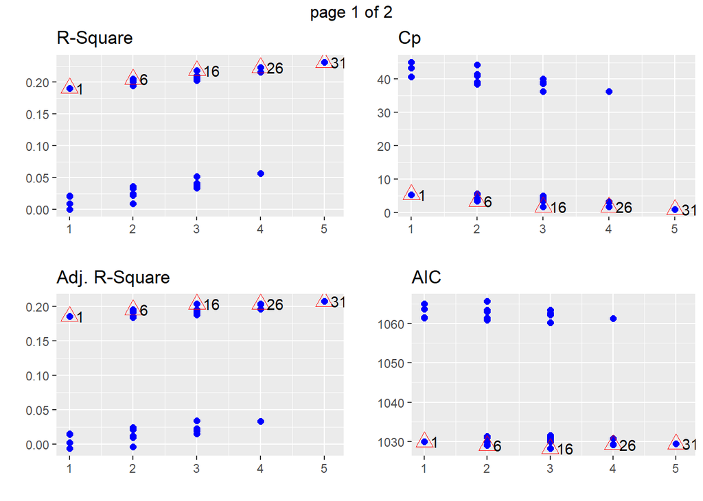

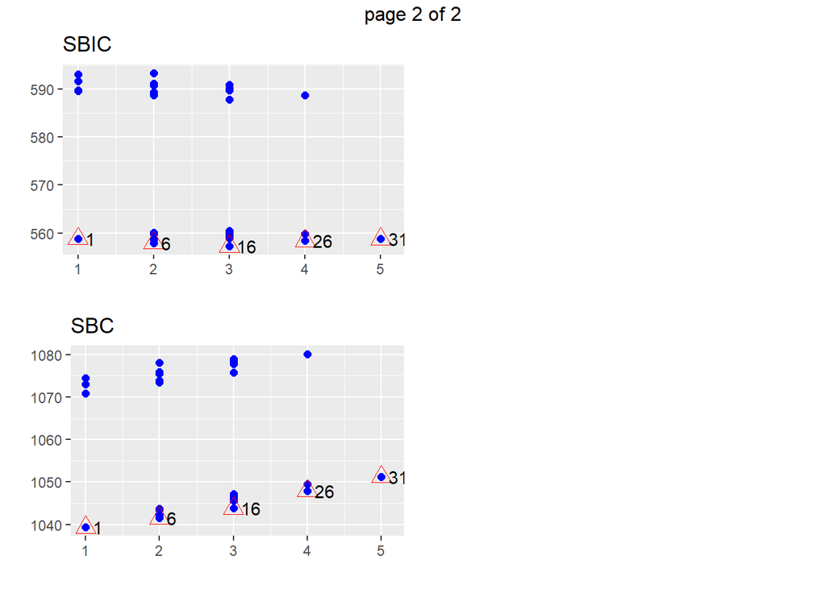

```r
kplot<-ols_step_all_possible(mod1)
plot(kplot)
```

The convention with model stats is usually maximise R-squared and minimise AIC and MSE. But for the best subset of variables, the package has readily made function, which we will try below.

```r
ols_step_best_subset(mod1)
```

```
##          Best Subsets Regression
## ------------------------------------------
## Model Index    Predictors
## ------------------------------------------
##      1         attitude
##      2         attitude stra
##      3         attitude Age stra
##      4         attitude Age deep stra
##      5         attitude Age deep stra surf
## ------------------------------------------
##
##                                                      Subsets Regression Summary
## -------------------------------------------------------------------------------------------------------------------------------------
##                        Adj.        Pred
## Model    R-Square    R-Square    R-Square     C(p)        AIC         SBIC         SBC         MSEP         FPE       HSP       APC
## -------------------------------------------------------------------------------------------------------------------------------------
##   1        0.1906      0.1856      0.1701    6.4442    1029.9875    558.8415    1039.3235    4697.7198    28.6404    0.1736    0.8292
##   2        0.2048      0.1951      0.1785    5.4776    1029.0379    557.9692    1041.4858    4643.4709    28.4772    0.1727    0.8245
##   3        0.2182      0.2037      0.1764    4.6969    1028.2247    557.2987    1043.7847    4593.7993    28.3381    0.1719    0.8204
##   4        0.2228      0.2035      0.1715    5.7310    1029.2363    558.4113    1047.9082    4595.0677    28.5116    0.1730    0.8255
##   5        0.2311      0.2071      0.1677    6.0000    1029.4500    558.8096    1051.2339    4574.4766    28.5487    0.1733    0.8265
## -------------------------------------------------------------------------------------------------------------------------------------
## AIC: Akaike Information Criteria
##  SBIC: Sawa's Bayesian Information Criteria
##  SBC: Schwarz Bayesian Criteria
##  MSEP: Estimated error of prediction, assuming multivariate normality
##  FPE: Final Prediction Error
##  HSP: Hocking's Sp
##  APC: Amemiya Prediction Criteria
```

LOL, more regression summary statistics than i care for! Lets try plotting this so its a bit more intuitive.

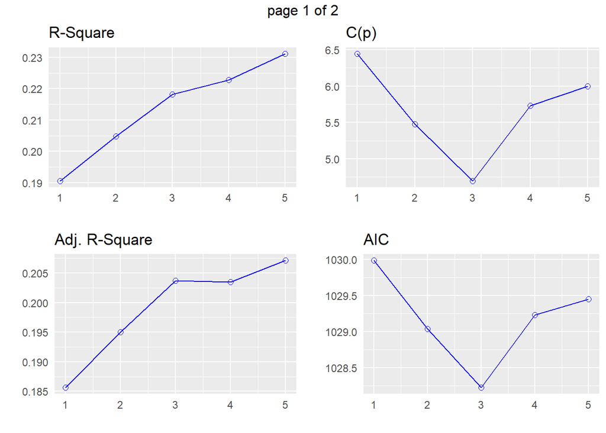

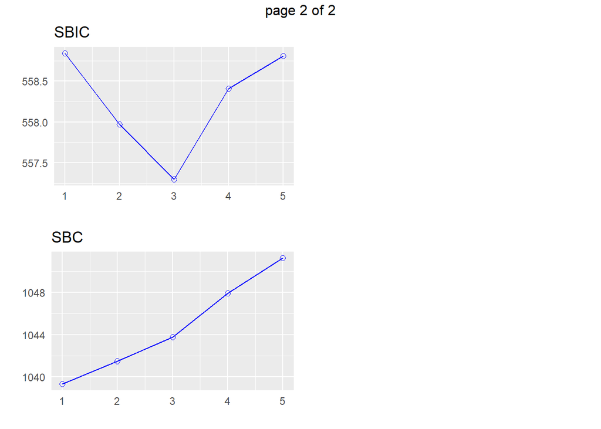

```r
kplot1<-ols_step_best_subset(mod1)
plot(kplot1)
```

##### **Stepwise backward regression** methods

```r
mod2<-lm(formula= Points ~ .,data=student2014)
summary(mod2)
```

```
##
## Call:
## lm(formula = Points ~ ., data = student2014)
##
## Residuals:
##      Min       1Q   Median       3Q      Max
## -17.4506  -3.2479   0.3879   3.5243  11.4820
##
## Coefficients:
##             Estimate Std. Error t value Pr(>|t|)
## (Intercept) 18.30246    5.25723   3.481 0.000644 ***
## genderM     -0.05858    0.92985  -0.063 0.949845
## Age         -0.09607    0.05396  -1.780 0.076929 .
## attitude     3.44300    0.59776   5.760 4.24e-08 ***
## deep        -1.04279    0.78438  -1.329 0.185606
## stra         0.95871    0.55150   1.738 0.084083 .
## surf        -1.10891    0.84467  -1.313 0.191132
## ---
## Signif. codes:  0 '***' 0.001 '**' 0.01 '*' 0.05 '.' 0.1 ' ' 1
##
## Residual standard error: 5.265 on 159 degrees of freedom
## Multiple R-squared:  0.2312, Adjusted R-squared:  0.2021
## F-statistic: 7.967 on 6 and 159 DF,  p-value: 1.599e-07
```

```r
#Notice slightly different function. This is choosing models on AIC.
ols_step_backward_aic(mod2)
```

```
##
##
##                       Backward Elimination Summary
## ----------------------------------------------------------------------
## Variable        AIC         RSS        Sum Sq      R-Sq      Adj. R-Sq
## ----------------------------------------------------------------------
## Full Model    1031.446    4408.344    1325.349    0.23115      0.20214
## gender        1029.450    4408.454    1325.239    0.23113      0.20710
## surf          1029.236    4456.149    1277.544    0.22281      0.20350
## deep          1028.225    4482.762    1250.931    0.21817      0.20369
## ----------------------------------------------------------------------
```

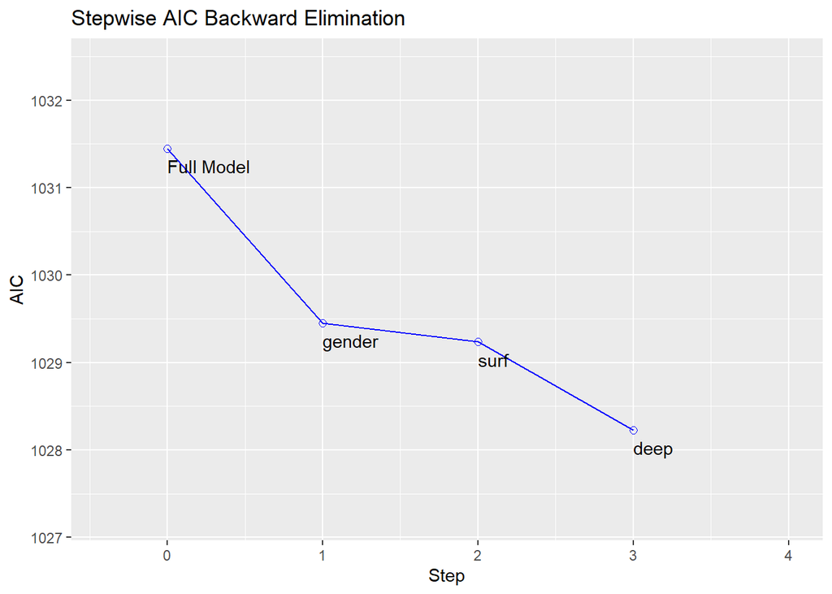

```r
kplot2<-ols_step_backward_aic(mod2)
plot(kplot2)
```

```r
#If we do it based on p value,
ols_step_backward_p(mod2)
```

```
##
##
##                            Elimination Summary
## -------------------------------------------------------------------------
##         Variable                  Adj.
## Step    Removed     R-Square    R-Square     C(p)        AIC        RMSE
## -------------------------------------------------------------------------
##    1    gender        0.2311      0.2071    5.0040    1029.4500    5.2491
## -------------------------------------------------------------------------
```

```r
#Only removes gender from the model, which is slightly different to backward selection based on AIC
```

The results of the step_backward_aic method matches with the best selection method above. I’d be happy to go with that. Hence the final model of choice based on the above two methods is below in final<-lm:

#====================================================================================================================

#### **Task 4 - Model interpretation**

```r
final<-lm(formula= Points ~ attitude+Age+stra,data=student2014)
summary(final)
```

```
##
## Call:
## lm(formula = Points ~ attitude + Age + stra, data = student2014)
##
## Residuals:
##      Min       1Q   Median       3Q      Max
## -18.1149  -3.2003   0.3303   3.4129  10.7599
##
## Coefficients:
##             Estimate Std. Error t value Pr(>|t|)
## (Intercept) 10.89543    2.64834   4.114 6.17e-05 ***
## attitude     3.48077    0.56220   6.191 4.72e-09 ***
## Age         -0.08822    0.05302  -1.664   0.0981 .
## stra         1.00371    0.53434   1.878   0.0621 .
## ---
## Signif. codes:  0 '***' 0.001 '**' 0.01 '*' 0.05 '.' 0.1 ' ' 1
##
## Residual standard error: 5.26 on 162 degrees of freedom
## Multiple R-squared:  0.2182, Adjusted R-squared:  0.2037
## F-statistic: 15.07 on 3 and 162 DF,  p-value: 1.07e-08
```

**Call:** This is the function that we are calling. Our final model that we are going to dissect below

**Residuals:** This tells us how well the model fits to the data. It tells us the distance of points away from the main regression line at 5 different places: Minimum, maximum, median, 1st quartile and 3rd quartile (all in units of distancee, rather than actual value).

**Signif.codes:** These relate to significance levels of p-value. Triple star means most significant, dots and space means less significant.

**Model fit stats** Stuff below the significance levels are about model performance statistics. The main one i look at is R-squared values (how much of the variance in the data did the model explain?). In this case its only around 20% - which is quite underwhelming. The difference between the multiple and adjusted R-squared is when penalty is applied to the number of independent variables included in the model. Ideally, we want R-squared values (particularly adjusted R-squared) value closer to 1, which would mean nearly all variability in data is explained by the model.

#====================================================================================================================

#### **Task 5 - Diagnostics**

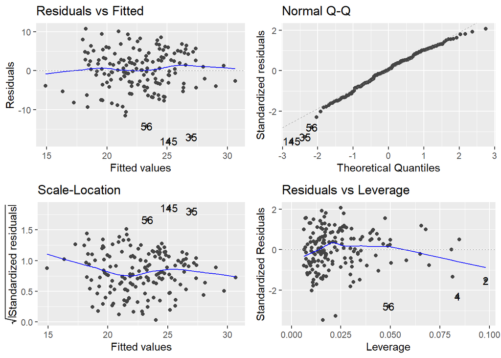

```r
library(ggfortify)
autoplot(final)
```

**Residuals vs Fitted** This shows if the residuals of the model have a normal distribution. If there are abnormal shapes (such as fanning, or curves), that usually indicates that the residuals aren’t normally distributed and therefore the model does not comply with the assumptions of the model (in linear regression this is a must). In this instance, it don’t see any fanning or curving, so that’s fine.

**Normal QQ plot** In this plot, we want to points to be perfectly aligned to the diagonal line, which would indicate a perfect fit. In our case, there are some parts of the data that does large deviation, which means model fit is not very good at the extreme ends. Particular outliers stand out, 56, 145 and 35 are row ids for some special cases in our data set. They do not comply well to the regression line!

**Residuals vs Leverage** This tells us about influence of individual data points (called leverage). Here, data points 4 and 2 (pulling the fitted line at one end) are big influencers (highest leverage). 56 is kind of in the middle, but very much an outlier still (from QQ plot).

#====================================================================================================================